# Analisis Hubungan Aktivitas Harian dan Waktu Tidur - Notebook

Damar Djati Wahyu Kemala

Update: 11 Desember 2022

### Import Library

```r
library(tidyverse) # untuk pengolahan data
library(ggplot2) # untuk visualisasi data
library(lubridate) # untuk re-format tanggal
library(dplyr) # untuk memanipulasi dataframe
library(corrr) # untuk mencari nilai korelasi antar variabel
```

### Mengambil Data dari locale disk

```r
DailyActivity <- read.csv("dailyActivity_merged.csv")
SleepDay <- read.csv("sleepDay_merged.csv")
```

### Check Nama Kolom

```
 [1] "Id"                       "ActivityDate"             "TotalSteps"
 [4] "TotalDistance"            "TrackerDistance"          "LoggedActivitiesDistance"
 [7] "VeryActiveDistance"       "ModeratelyActiveDistance" "LightActiveDistance"
[10] "SedentaryActiveDistance"  "VeryActiveMinutes"        "FairlyActiveMinutes"
[13] "LightlyActiveMinutes"     "SedentaryMinutes"         "Calories"
```

```
[1] "Id"                 "SleepDay"           "TotalSleepRecords"  "TotalMinutesAsleep" "TotalTimeInBed"
```

### Check 5 Data Teratas

Mengecek 5 data teratas pada dataframe `daily activity`

|  | Id | ActivityDate | TotalSteps | TotalDistance | TrackerDistance | LoggedActivitiesDistance | VeryActiveDistance | ModeratelyActiveDistance | LightActiveDistance | SedentaryActiveDistance | VeryActiveMinutes | FairlyActiveMinutes | LightlyActiveMinutes | SedentaryMinutes | Calories |
| --- | --- | --- | --- | --- | --- | --- | --- | --- | --- | --- | --- | --- | --- | --- | --- |
| 1 | 1503960366 | 4/12/2016 | 13162 | 8.50 | 8.50 | 0 | 1.88 | 0.55 | 6.06 | 0 | 25 | 13 | 328 | 728 | 1985 |
| 2 | 1503960366 | 4/13/2016 | 10735 | 6.97 | 6.97 | 0 | 1.57 | 0.69 | 4.71 | 0 | 21 | 19 | 217 | 776 | 1797 |
| 3 | 1503960366 | 4/14/2016 | 10460 | 6.74 | 6.74 | 0 | 2.44 | 0.40 | 3.91 | 0 | 30 | 11 | 181 | 1218 | 1776 |
| 4 | 1503960366 | 4/15/2016 | 9762 | 6.28 | 6.28 | 0 | 2.14 | 1.26 | 2.83 | 0 | 29 | 34 | 209 | 726 | 1745 |
| 5 | 1503960366 | 4/16/2016 | 12669 | 8.16 | 8.16 | 0 | 2.71 | 0.41 | 5.04 | 0 | 36 | 10 | 221 | 773 | 1863 |

Mengecek 5 data teratas pada dataframe `sleep Day`

|  | Id | SleepDay | TotalSleepRecords | TotalMinutesAsleep | TotalTimeInBed |
| --- | --- | --- | --- | --- | --- |
| 1 | 1503960366 | 4/12/2016 12:00:00 AM | 1 | 327 | 346 |
| 2 | 1503960366 | 4/13/2016 12:00:00 AM | 2 | 384 | 407 |
| 3 | 1503960366 | 4/15/2016 12:00:00 AM | 1 | 412 | 442 |
| 4 | 1503960366 | 4/16/2016 12:00:00 AM | 2 | 340 | 367 |
| 5 | 1503960366 | 4/17/2016 12:00:00 AM | 1 | 700 | 712 |

### Check Struktur Data pada Dataframe

Struktur data pada dataframe `daily activity`

```
'data.frame':   940 obs. of  15 variables:
 $ Id                      : num  1.5e+09 1.5e+09 1.5e+09 1.5e+09 1.5e+09 ...
 $ ActivityDate            : chr  "4/12/2016" "4/13/2016" "4/14/2016" "4/15/2016" ...
 $ TotalSteps              : int  13162 10735 10460 9762 12669 9705 13019 15506 10544 9819 ...
 $ TotalDistance           : num  8.5 6.97 6.74 6.28 8.16 ...
 $ TrackerDistance         : num  8.5 6.97 6.74 6.28 8.16 ...
 $ LoggedActivitiesDistance: num  0 0 0 0 0 0 0 0 0 0 ...
 $ VeryActiveDistance      : num  1.88 1.57 2.44 2.14 2.71 ...
 $ ModeratelyActiveDistance: num  0.55 0.69 0.4 1.26 0.41 ...
 $ LightActiveDistance     : num  6.06 4.71 3.91 2.83 5.04 ...
 $ SedentaryActiveDistance : num  0 0 0 0 0 0 0 0 0 0 ...
 $ VeryActiveMinutes       : int  25 21 30 29 36 38 42 50 28 19 ...
 $ FairlyActiveMinutes     : int  13 19 11 34 10 20 16 31 12 8 ...
 $ LightlyActiveMinutes    : int  328 217 181 209 221 164 233 264 205 211 ...
 $ SedentaryMinutes        : int  728 776 1218 726 773 539 1149 775 818 838 ...
 $ Calories                : int  1985 1797 1776 1745 1863 1728 1921 2035 1786 1775 ...
```

Struktur data pada dataframe `Sleep Day`

```
'data.frame':   413 obs. of  5 variables:
 $ Id                : num  1.5e+09 1.5e+09 1.5e+09 1.5e+09 1.5e+09 ...
 $ SleepDay          : chr  "4/12/2016 12:00:00 AM" "4/13/2016 12:00:00 AM" "4/15/2016 12:00:00 AM" "4/16/2016 12:00:00 AM" ...
 $ TotalSleepRecords : int  1 2 1 2 1 1 1 1 1 1 ...
 $ TotalMinutesAsleep: int  327 384 412 340 700 304 360 325 361 430 ...
 $ TotalTimeInBed    : int  346 407 442 367 712 320 377 364 384 449 ...
```

### Menjelajahi Setiap Kolom dan isi pada Tabel

Mengecek jumlah kolom pada dataframe/tabel `dailyActivity` dan `sleepDay`

```
[1] "Jumlah kolom (Daily Activity) = 15"
[1] "Jumlah kolom (Sleep Day) = 5"
[1] "Jumlah baris (Daily Activity) = 940"
[1] "Jumlah baris (Sleep Day) = 413"
```

Mengecek jumlah nilai yang unik disetiap observasi pada dataframe `dailyActivity` dan `SleepDay`

```
[1] "Jumlah Baris Nilai Unik (Daily Activity): 33"
[1] "Jumlah Baris Nilai Unik (Sleep Day): 24"
```

### Ringkasan Statistik

Ringkasan nilai statistik pada dataframe `daily activity`

```
   TotalSteps    TotalDistance    SedentaryMinutes
 Min.   :    0   Min.   : 0.000   Min.   :   0.0
 1st Qu.: 3790   1st Qu.: 2.620   1st Qu.: 729.8
 Median : 7406   Median : 5.245   Median :1057.5
 Mean   : 7638   Mean   : 5.490   Mean   : 991.2
 3rd Qu.:10727   3rd Qu.: 7.713   3rd Qu.:1229.5
 Max.   :36019   Max.   :28.030   Max.   :1440.0
```

```
 LoggedActivitiesDistance SedentaryActiveDistance
 Min.   :0.0000           Min.   :0.000000
 1st Qu.:0.0000           1st Qu.:0.000000
 Median :0.0000           Median :0.000000
 Mean   :0.1082           Mean   :0.001606
 3rd Qu.:0.0000           3rd Qu.:0.000000
 Max.   :4.9421           Max.   :0.110000
```

Ringkasan nilai statistik pada dataframe `sleep day`

```
 TotalTimeInBed  TotalSleepRecords TotalMinutesAsleep
 Min.   : 61.0   Min.   :1.000     Min.   : 58.0
 1st Qu.:403.0   1st Qu.:1.000     1st Qu.:361.0
 Median :463.0   Median :1.000     Median :433.0
 Mean   :458.6   Mean   :1.119     Mean   :419.5
 3rd Qu.:526.0   3rd Qu.:1.000     3rd Qu.:490.0
 Max.   :961.0   Max.   :3.000     Max.   :796.0
```

### Data Cleaning

Menghapus kolom `LoggedActivitiesDistance` dan kolom `SedentaryActiveDistance` pada dataframe `daily activity` karena dari segi analisis statistik hampir semua nilai mendekati 0.

```
'data.frame':   940 obs. of  13 variables:
 $ Id                      : num  1.5e+09 1.5e+09 1.5e+09 1.5e+09 1.5e+09 ...
 $ ActivityDate            : chr  "4/12/2016" "4/13/2016" "4/14/2016" "4/15/2016" ...
 $ TotalSteps              : int  13162 10735 10460 9762 12669 9705 13019 15506 10544 9819 ...
 $ TotalDistance           : num  8.5 6.97 6.74 6.28 8.16 ...
 $ TrackerDistance         : num  8.5 6.97 6.74 6.28 8.16 ...
 $ VeryActiveDistance      : num  1.88 1.57 2.44 2.14 2.71 ...
 $ ModeratelyActiveDistance: num  0.55 0.69 0.4 1.26 0.41 ...
 $ LightActiveDistance     : num  6.06 4.71 3.91 2.83 5.04 ...
 $ VeryActiveMinutes       : int  25 21 30 29 36 38 42 50 28 19 ...
 $ FairlyActiveMinutes     : int  13 19 11 34 10 20 16 31 12 8 ...
 $ LightlyActiveMinutes    : int  328 217 181 209 221 164 233 264 205 211 ...
 $ SedentaryMinutes        : int  728 776 1218 726 773 539 1149 775 818 838 ...
 $ Calories                : int  1985 1797 1776 1745 1863 1728 1921 2035 1786 1775 ...
```

Melakukan re-format pada kolom ActivityDate di dataframe `daily activity` dan kolom `sleepday` pada dataframe `Sleep Day`

```r
DailyActivity$ActivityDate <- as.Date(DailyActivity$ActivityDate, format = "%m/%d/%Y")

SleepDay$SleepDay <- as.Date(SleepDay$SleepDay, "%m/%d/%Y %H:%M:%S")

# is.Date(DailyActivity$ActivityDate)
# is.Date(SleepDay$SleepDay)
```

Memisahkan data tanggal khususnya hari, bulan, dan tahun ke kolom baru pada dataframe `sleep Day`

|  | Id | SleepDay | TotalSleepRecords | TotalMinutesAsleep | TotalTimeInBed | Day | DayName | Month | Year |
| --- | --- | --- | --- | --- | --- | --- | --- | --- | --- |
| 1 | 1503960366 | 2016-04-12 | 1 | 327 | 346 | 12 | Tuesday | 04 | 2016 |
| 2 | 1503960366 | 2016-04-13 | 2 | 384 | 407 | 13 | Wednesday | 04 | 2016 |
| 3 | 1503960366 | 2016-04-15 | 1 | 412 | 442 | 15 | Friday | 04 | 2016 |
| 4 | 1503960366 | 2016-04-16 | 2 | 340 | 367 | 16 | Saturday | 04 | 2016 |
| 5 | 1503960366 | 2016-04-17 | 1 | 700 | 712 | 17 | Sunday | 04 | 2016 |
| 6 | 1503960366 | 2016-04-19 | 1 | 304 | 320 | 19 | Tuesday | 04 | 2016 |

Memisahkan data tanggal khususnya hari, bulan, dan tahun ke kolom baru pada dataframe `Daily Activity`

|  | Id | ActivityDate | TotalSteps | TotalDistance | TrackerDistance | VeryActiveDistance | ModeratelyActiveDistance | LightActiveDistance | VeryActiveMinutes | FairlyActiveMinutes | LightlyActiveMinutes | SedentaryMinutes | Calories | Day | DayName | Month | Year |
| --- | --- | --- | --- | --- | --- | --- | --- | --- | --- | --- | --- | --- | --- | --- | --- | --- | --- |
| 1 | 1503960366 | 2016-04-12 | 13162 | 8.50 | 8.50 | 1.88 | 0.55 | 6.06 | 25 | 13 | 328 | 728 | 1985 | 12 | Tuesday | 04 | 2016 |
| 2 | 1503960366 | 2016-04-13 | 10735 | 6.97 | 6.97 | 1.57 | 0.69 | 4.71 | 21 | 19 | 217 | 776 | 1797 | 13 | Wednesday | 04 | 2016 |
| 3 | 1503960366 | 2016-04-14 | 10460 | 6.74 | 6.74 | 2.44 | 0.40 | 3.91 | 30 | 11 | 181 | 1218 | 1776 | 14 | Thursday | 04 | 2016 |
| 4 | 1503960366 | 2016-04-15 | 9762 | 6.28 | 6.28 | 2.14 | 1.26 | 2.83 | 29 | 34 | 209 | 726 | 1745 | 15 | Friday | 04 | 2016 |
| 5 | 1503960366 | 2016-04-16 | 12669 | 8.16 | 8.16 | 2.71 | 0.41 | 5.04 | 36 | 10 | 221 | 773 | 1863 | 16 | Saturday | 04 | 2016 |
| 6 | 1503960366 | 2016-04-17 | 9705 | 6.48 | 6.48 | 3.19 | 0.78 | 2.51 | 38 | 20 | 164 | 539 | 1728 | 17 | Sunday | 04 | 2016 |

### Check Korelasi Antar Kolom Data pada DataFrame Daily Activity

```
Non-numeric variables removed from input: `ActivityDate`, `Day`, `DayName`, `Month`, and `Year`
Correlation computed with
* Method: 'pearson'
* Missing treated using: 'pairwise.complete.obs'
```

| term | TotalSteps | Calories |
| --- | --- | --- |
| Id | 0.2139642 | 0.45375888 |
| TotalDistance | 0.9826464 | 0.62423802 |
| TrackerDistance | 0.9819287 | 0.62465103 |
| VeryActiveDistance | 0.7544861 | 0.48290637 |
| ModeratelyActiveDistance | 0.4795747 | 0.17860861 |
| LightActiveDistance | 0.6048838 | 0.40818409 |
| VeryActiveMinutes | 0.6639646 | 0.61223493 |
| FairlyActiveMinutes | 0.4653678 | 0.26394560 |
| LightlyActiveMinutes | 0.4359532 | 0.17881369 |
| SedentaryMinutes | -0.1861734 | -0.02825836 |

### Check Korelasi Antar Kolom Data pada DataFrame Sleep Day

```
Non-numeric variables removed from input: `SleepDay`, `Day`, `DayName`, `Month`, and `Year`
Correlation computed with
* Method: 'pearson'
* Missing treated using: 'pairwise.complete.obs'
```

| term | Id | TotalSleepRecords | TotalMinutesAsleep | TotalTimeInBed |
| --- | --- | --- | --- | --- |
| Id | NA | -0.01255213 | 0.0801170 | 0.002111623 |
| TotalSleepRecords | -0.012552132 | NA | 0.1659119 | 0.172917328 |
| TotalMinutesAsleep | 0.080116998 | 0.16591191 | NA | 0.930457454 |
| TotalTimeInBed | 0.002111623 | 0.17291733 | 0.9304575 | NA |

### Analisis-1 Dengan Dataset terpisah

**Pada dataset Daily Activity**, Melihat korelasi antara `banyaknya aktivitas` yang diambil terhadap saat kita dalam posisi diam dalam hitungan menit. Dan bagaimana ini dapat membantu customer ? seperti apakah setiap orang diharuskan lebih banyak bergerak atau diam/duduk-duduk saja untuk membakar kalori agar tubuh tetap sehat?

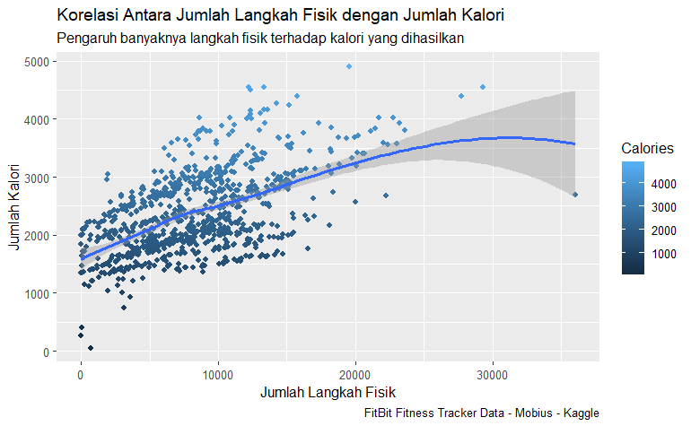

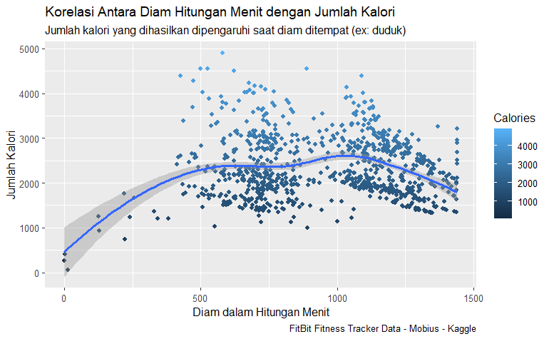

**Pada dataset Sleep Day**, Apakah terdapat korelasi antara `jumlah menit saat tidur` dengan `banyaknya waktu saat ditempat tidur`? Apakah terdapat tren secara linear?

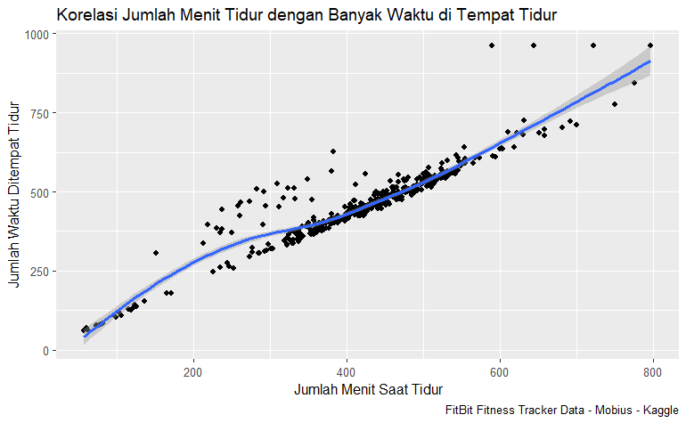

### Analisis-2 Menggabungkan Dataset berdasarkan Id

Mencari hubungan antara waktu tidur dan aktivitas yang dilakukan.

Data Tahun : 2016

|  | Id | ActivityDate | TotalSteps | TotalDistance | TrackerDistance | VeryActiveDistance | ModeratelyActiveDistance | LightActiveDistance | VeryActiveMinutes | FairlyActiveMinutes | LightlyActiveMinutes | SedentaryMinutes | Calories | Day.x | DayName.x | Month.x | Year.x | SleepDay | TotalSleepRecords | TotalMinutesAsleep | TotalTimeInBed | Day.y | DayName.y | Month.y | Year.y |
| --- | --- | --- | --- | --- | --- | --- | --- | --- | --- | --- | --- | --- | --- | --- | --- | --- | --- | --- | --- | --- | --- | --- | --- | --- | --- |
| 1 | 1503960366 | 2016-04-19 | 15506 | 9.88 | 9.88 | 3.53 | 1.32 | 5.03 | 50 | 31 | 264 | 775 | 2035 | 19 | Tuesday | 04 | 2016 | 2016-04-12 | 1 | 327 | 346 | 12 | Tuesday | 04 | 2016 |
| 2 | 1503960366 | 2016-04-19 | 15506 | 9.88 | 9.88 | 3.53 | 1.32 | 5.03 | 50 | 31 | 264 | 775 | 2035 | 19 | Tuesday | 04 | 2016 | 2016-04-13 | 2 | 384 | 407 | 13 | Wednesday | 04 | 2016 |
| 3 | 1503960366 | 2016-04-19 | 15506 | 9.88 | 9.88 | 3.53 | 1.32 | 5.03 | 50 | 31 | 264 | 775 | 2035 | 19 | Tuesday | 04 | 2016 | 2016-04-15 | 1 | 412 | 442 | 15 | Friday | 04 | 2016 |
| 4 | 1503960366 | 2016-04-19 | 15506 | 9.88 | 9.88 | 3.53 | 1.32 | 5.03 | 50 | 31 | 264 | 775 | 2035 | 19 | Tuesday | 04 | 2016 | 2016-04-16 | 2 | 340 | 367 | 16 | Saturday | 04 | 2016 |
| 5 | 1503960366 | 2016-04-19 | 15506 | 9.88 | 9.88 | 3.53 | 1.32 | 5.03 | 50 | 31 | 264 | 775 | 2035 | 19 | Tuesday | 04 | 2016 | 2016-04-17 | 1 | 700 | 712 | 17 | Sunday | 04 | 2016 |
| 6 | 1503960366 | 2016-04-19 | 15506 | 9.88 | 9.88 | 3.53 | 1.32 | 5.03 | 50 | 31 | 264 | 775 | 2035 | 19 | Tuesday | 04 | 2016 | 2016-04-19 | 1 | 304 | 320 | 19 | Tuesday | 04 | 2016 |

Korelasi `total distance` dengan `jumlah kalori yang dibakar`, apakah dengan semakin jauh jarak yang ditempuh kalori akan semakin banyak yang terbakar?

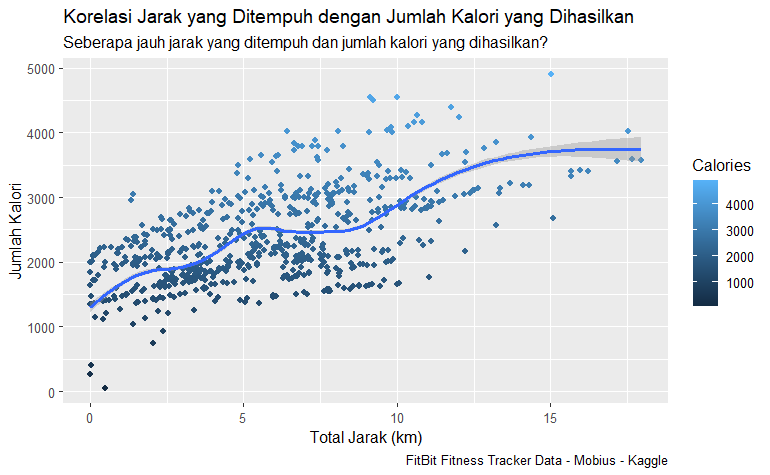

Menghapus Kolom yang tidak diperlukan.

Pada dataframe `full_data` cukup menggunakan kolom :

- DayName.x
- TotalSteps
- Calories
- TotalMinutesAsleep

|  | DayName.x | TotalSteps | Calories | TotalMinutesAsleep |
| --- | --- | --- | --- | --- |
| 176 | Sunday | 10602 | 1820 | 327 |
| 177 | Sunday | 10602 | 1820 | 384 |
| 178 | Sunday | 10602 | 1820 | 412 |
| 179 | Sunday | 10602 | 1820 | 340 |
| 180 | Sunday | 10602 | 1820 | 700 |
| 181 | Sunday | 10602 | 1820 | 304 |

### Hubungan Antara Waktu Tidur dengan Aktivitas yang dilakukan

Perlu mengubah kembali format TotalMinutesAsleep menjadi Jam.

Dengan menambahkan kolom baru `TotalHoursAsleep`

Persentase Aktivitas yang dilakukan

| Day | TotalSteps | Calories | TotalHoursAsleep | PercentSteps | PercentHoursSleep | PercentCalories |
| --- | --- | --- | --- | --- | --- | --- |
| Sunday | 10672927 | 3346834 | 9543 | 10.57 | 12.46 | 11.97 |
| Monday | 13992478 | 3712362 | 9861 | 13.86 | 12.88 | 13.28 |
| Tuesday | 18151529 | 4719235 | 12308 | 17.97 | 16.07 | 16.88 |
| Wednesday | 15667215 | 4454940 | 12470 | 15.51 | 16.29 | 15.93 |
| Thursday | 15007480 | 4173953 | 11991 | 14.86 | 15.66 | 14.93 |
| Friday | 13483875 | 3827284 | 10370 | 13.35 | 13.54 | 13.69 |

#### Persentase Aktivitas Fisik per Hari

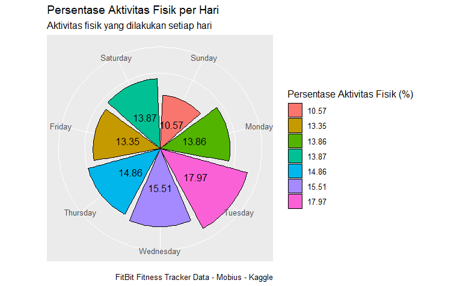

#### Persentase Waktu Tidur per Hari

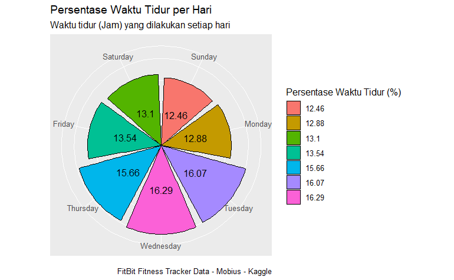

#### Persentase Kalori per Hari

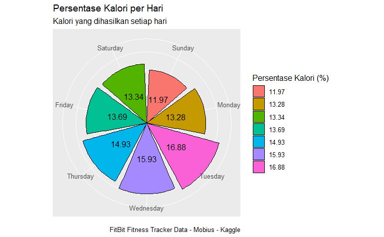